# Estadística multivariable: correlación, componentes principales y grupos

Unidad 3 · Regresión · Geoquímica de rocas con datos de EarthChem PetDB

Cristoffer Rumiguano, Ana Gabriela Fernández, Evelyn Bustamante, Jessica Haro, Jhonattan Ligña

Noviembre de 2026

> Proyecto estrictamente académico (Estadística y Probabilidades, FIGEMPA – UCE). Datos: EarthChem PetDB (CC BY 4.0), descargados el 13/10/2026. Web del proyecto: https://crisrumiguano-art.github.io/geoquimica-earthchem-ml/

## 1. Carga de datos

Se usa la base completa (159 760 análisis). Para cada par se toman solo las filas que tienen **los dos** datos: no se inventa ningún valor que falte.

```r
knitr::opts_chunk$set(echo = TRUE, message = FALSE, warning = FALSE, fig.align = "center")
if (!file.exists("data/earthchem_limpio.csv.gz")) {
  dir.create("data", showWarnings = FALSE)
  download.file("https://github.com/crisrumiguano-art/geoquimica-earthchem-ml/raw/main/data/earthchem_limpio.csv.gz", "data/earthchem_limpio.csv.gz", mode = "wb")
}
base <- read.csv(gzfile("data/earthchem_limpio.csv.gz", encoding = "UTF-8"), check.names = FALSE)
dim(base)
```

```
## [1] 159760     75
```

## 2. Asignación de variables

Los 8 óxidos mayores de las rocas ígneas con los 8 completos. Todos a la vez: ya no un par, sino la estructura completa de la química de la roca.

```r
oxidos <- c("SiO2 (wt%)", "Al2O3 (wt%)", "MgO (wt%)", "CaO (wt%)", "Na2O (wt%)", "K2O (wt%)", "P2O5 (wt%)", "MnO (wt%)")
ignea <- grepl("^igneous", base[["Sample Type"]])
datos <- na.omit(base[ignea, c(oxidos, "Sample Type")])
X <- datos[, oxidos]
colnames(X) <- sub(" [(]wt%[)]", "", colnames(X))      # nombres cortos: SiO2, Al2O3, ...
tipo <- sub("igneous:", "", datos[["Sample Type"]])   # volcanic:mafic, plutonic:ultramafic, ...
nrow(X)
```

```
## [1] 36420
```

## 3. Matriz de correlación

```r
R <- cor(X)
knitr::kable(round(R, 2), caption = "Tabla N° 1: matriz de correlación de los óxidos mayores")
```

Tabla N° 1: matriz de correlación de los óxidos mayores

|  | SiO2 | Al2O3 | MgO | CaO | Na2O | K2O | P2O5 | MnO |
| --- | --- | --- | --- | --- | --- | --- | --- | --- |
| SiO2 | 1.00 | 0.24 | -0.49 | -0.54 | 0.48 | 0.57 | -0.13 | -0.05 |
| Al2O3 | 0.24 | 1.00 | -0.67 | 0.32 | 0.43 | 0.15 | 0.01 | -0.05 |
| MgO | -0.49 | -0.67 | 1.00 | -0.14 | -0.58 | -0.37 | -0.01 | -0.04 |
| CaO | -0.54 | 0.32 | -0.14 | 1.00 | -0.25 | -0.56 | 0.04 | -0.02 |
| Na2O | 0.48 | 0.43 | -0.58 | -0.25 | 1.00 | 0.58 | 0.03 | -0.01 |
| K2O | 0.57 | 0.15 | -0.37 | -0.56 | 0.58 | 1.00 | 0.05 | -0.02 |
| P2O5 | -0.13 | 0.01 | -0.01 | 0.04 | 0.03 | 0.05 | 1.00 | 0.05 |
| MnO | -0.05 | -0.05 | -0.04 | -0.02 | -0.01 | -0.02 | 0.05 | 1.00 |

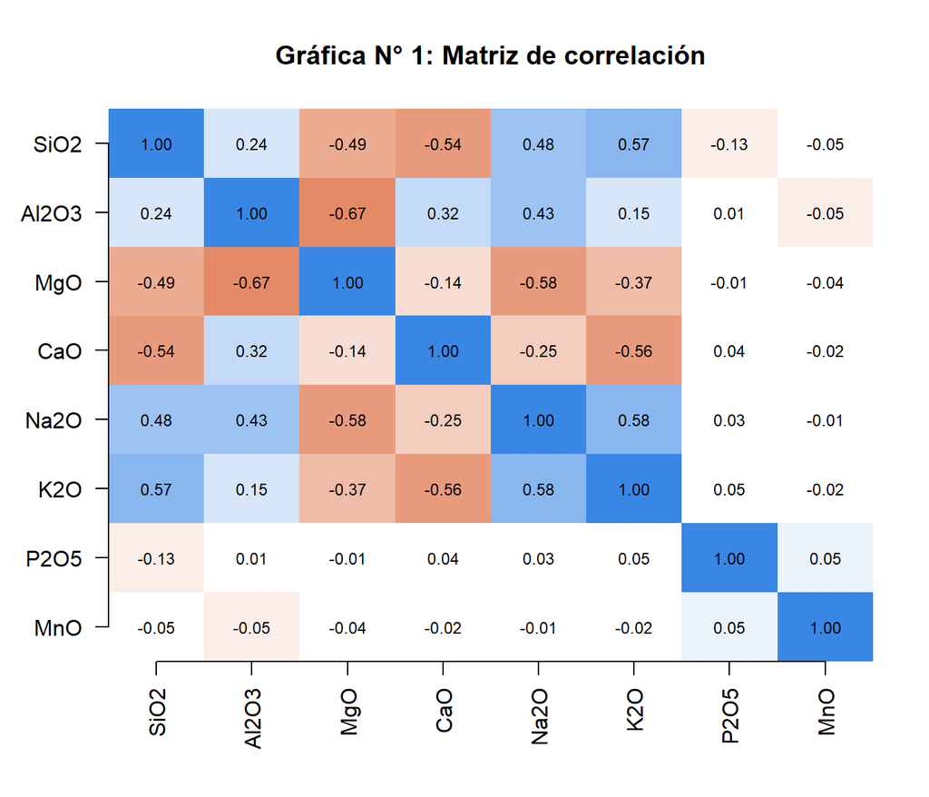

```r
colores <- colorRampPalette(c("#d95926", "white", "#3987e5"))(21)
image(1:8, 1:8, R[, 8:1], col = colores, zlim = c(-1, 1), axes = FALSE, xlab = "", ylab = "",
      main = "Gráfica N° 1: Matriz de correlación")
axis(1, 1:8, colnames(R), las = 2); axis(2, 1:8, rev(colnames(R)), las = 1)
text(rep(1:8, 8), rep(8:1, each = 8), sprintf("%.2f", R), cex = 0.75)
```

El SiO2 se opone al MgO (r = -0.49), y los álcalis (Na2O, K2O) acompañan a la sílice: es la diferenciación magmática de la Unidad 3, ahora vista con todas las variables juntas.